# Machine Learning Pipelines with Sparklyr and Spark ML

# Training Machine Learning Algorithms with Sparklyr

Since Spark 1.3, there has been much interest in creating a simple, interactive machine learning pipeline that represents a full data science application from start to end. The `mllib` package was created to address this need.

Looks very similar to the python `scikit-learn` package. For more of the available functionality, refer to [sparklyr-ml](http://spark.rstudio.com/mllib.html) website.

# Create Training and Split

In addition to modeling functions, there are numerous `mllib` functions for pre-processing and transformations. Here’s well use the partition function to split our data into training and test sets.

```r
partitions <- sample_taxi %>%
  sdf_partition(training = 0.75, test = 0.25, seed = 1099)
```

# Fit MLlib Linear Model

```r
fit <- partitions$training %>%
  filter(tip_pct < 0.5) %>%
  ml_linear_regression(response = "tip_pct", features = c("trip_distance"))
```

# Plot Results

This may not work for larger datasets, but for our current example we can select the two columns we used in our model, and bring them into local memory for visualization.

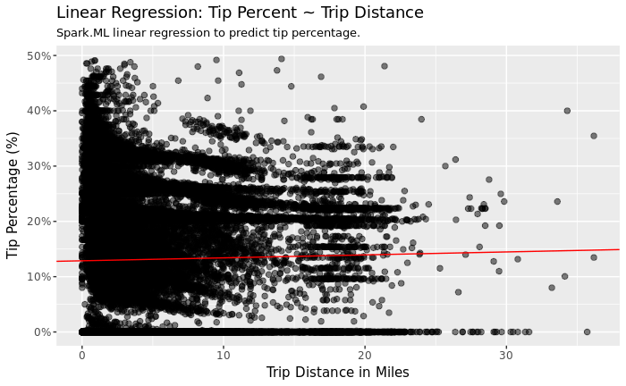

```r
library(ggplot2)
partitions$test %>%
  select(tip_pct, trip_distance) %>%
  filter(tip_pct < 0.5) %>%
  sample_n(10^5) %>%
  collect %>%
  ggplot(aes(trip_distance, tip_pct)) +
  geom_point(size = 2, alpha = 0.5) +
  geom_abline(aes(slope = coef(fit)[["trip_distance"]],
                  intercept = coef(fit)[["(Intercept)"]]),
              color = "red") +
  scale_y_continuous(label = scales::percent) +
  labs(
    x = "Trip Distance in Miles",
    y = "Tip Percentage (%)",
    title = "Linear Regression: Tip Percent ~ Trip Distance",
    subtitle = "Spark.ML linear regression to predict tip percentage."
  )
```

# Classification Tree

Try out a binary classification model using the ensemble tree algoritms.

Let’s first create a binary column to use as our response variable:

```r
taxi_binary <- sample_taxi %>%
  ft_binarizer(input_col = "tip_pct",
               output_col = "good_tip",
               threshold = 0.1)
partitions <- taxi_binary %>%
  sdf_partition(training = 0.75, test = 0.25, seed = 1099)
```

Train a tree model

```r
system.time(
fit_dtree <- partitions$training %>%
  ml_decision_tree(response = "good_tip",
                   features = c("payment_type", "passenger_count", "trip_distance"),
                   type = "classification")
)
```

```
* No rows dropped by 'na.omit' call
```

```
   user  system elapsed
  0.288   0.192  65.961
```

Let’s try predicting with the fitted decision tree model:

```r
score_dtree <- sdf_predict(fit_dtree, partitions$test)
```

That was for a single tree. Let’s try to train a ensemble tree using the random forest function:

```r
system.time(
  fit_dforest <- partitions$training %>%
  ml_random_forest(response = "good_tip",
                   features = c("payment_type", "passenger_count", "trip_distance"),
                   type = "classification")
)
```

```
* No rows dropped by 'na.omit' call
```

```
   user  system elapsed
  1.104   0.356  95.478
```

```r
score_dforest <- sdf_predict(fit_dforest, partitions$test)
```

# Create a Confusion Matrix

Now that we have our predicted results, we could create a confusion matrix of our predictions vs the actuals.

If we want to work entirely with Spark DataFrames, we can use the `sdf_predict` function and then group_by the predictions and actual values:

```r
sdf_conf_df <- function(predictions = score_dtree) {

  conf_sdf <- predictions %>% group_by(prediction, good_tip) %>% tally()

  return(conf_sdf)

}
dtree_conf_df <- sdf_conf_df() %>% collect
library(tidyr)
conf_spread <- . %>% spread(key = "good_tip", value  = "n")
dtree_conf <- dtree_conf_df %>% conf_spread
# create ratios for confusion matrix
dtree_conf <- dtree_conf[, 2:3]
dtree_conf/sum(dtree_conf)
```

| 0 | 1 |
| --- | --- |
| 0.36847398 | 1.918509e-05 |
| 0.05925029 | 5.722566e-01 |

## Using the Spark ML Model Metric Functions

We can use the SparkML evaluation module to calculate evaluation metrics directly from our scored data.

```r
dtree_auc <- ml_binary_classification_eval(predicted_tbl_spark = score_dtree, label = "good_tip", score = "probability")
dforest_auc <- ml_binary_classification_eval(predicted_tbl_spark = score_dforest, label = "good_tip", score = "probability")
### metric choices: c("f1", "precision", "recall", "weightedPrecision", "weightedRecall", "accuracy")
dforest_accuracy <- ml_classification_eval(predicted_tbl_spark = score_dforest, label = "good_tip", predicted_lbl = "prediction", metric = "accuracy")
sprintf("The AUC for the decision tree is %s", dtree_auc)
```

```
[1] "The AUC for the decision tree is 0.948804849240284"
```

```r
sprintf("The AUC for the random forest is %s", dforest_auc)
```

```
[1] "The AUC for the random forest is 0.948256711385144"
```

```r
sprintf("The accuracy of the random forest is %s", dforest_accuracy)
```

```
[1] "The accuracy of the random forest is 0.940731109871122"
```